# RNAseqDemo

Matt Cannon

08/31/2023

```r
library(edgeR)
library(tidyverse)
```

```r
theme_set(theme_bw())
theme_update(plot.title = element_text(hjust = 0.5))
library(qvalue)
```

## Make up directory structure

```bash
for directoryName in \
    misc \
    slurmOut \
    input/fastqs \
    output/fastqc \
    output/multiqc \
    output/align \
    output/geneCounts \
    output/figures \
    output/rdata \
    output/de \
    output/gsea
do
  if [ ! -d ${directoryName} ]
  then
    mkdir -p ${directoryName}
  fi
done
```

# Overview

This is a demo of an RNAseq analysis. We are analyzing data from this paper: “Nrf2 contributes to the weight gain of mice during space travel” https://www.ncbi.nlm.nih.gov/pmc/articles/PMC7479603/

The data are available on GEO and SRA: https://www.ncbi.nlm.nih.gov/geo/query/acc.cgi?acc=GSE152382 https://www.ncbi.nlm.nih.gov/Traces/study/?acc=PRJNA639142

I downloaded metadata including the SRA run accessions and saved it as a CSV named “misc/MiiiceIiiiinSpaaaaaaaaaaaaace.csv”.

We can use this to download the raw fastq data from SRA that we’ll use through the rest of this demo. We will also use the metadata during the analysis to define groups.

# Samples

We are going to analyze the RNAseq data from the thymus of four groups of mice.

- Boring wildtype C57BL/6 mice left on earth
- Terrestrial mutant Nrf2 knockout mice left on earth
- C57BL/6 astronaut mice launched into orbit for 31 days
- Mutant mice from outspace with Nrf2 knocked out launched into orbit for 31 days

# Analyses

## Get the data

I’m using prefetch and fasterq-dump to get the raw fastq files

```bash
sbatch sbatchCmds/getSRAData.sh
```

```
## Submitted batch job 3993932
```

## Quality control

### Look at some of the data directly

```bash
zcat input/fastqs/SRR12005052.fastq.gz | head -n 40
```

```
## @SRR12005052.1 HISEQ:795:HFHYVBCX2:1:1101:3977:1996 length=76
## NGCATATGTCATCTTTAAACTGCATTCCACAGTCTATAGTTCTTTTTTTTAACATACAATCGAGTAACAAACTCTC
## +SRR12005052.1 HISEQ:795:HFHYVBCX2:1:1101:3977:1996 length=76
## #<<DDHIHIIIIIGHHIIIIHHHHIIIIIIIIGHIHIIIIIIHHIHIIIIIIIHHHIIIIIHHGEHIHGHE?GEF@
## @SRR12005052.2 HISEQ:795:HFHYVBCX2:1:1101:8309:1991 length=76
## NGGGAAATGGAAAGGAAGAGATGTAGACGAATATAGATGTGGAGAATGGAAGGAGAGGGGAAGGAAAAAAGAGACT
## +SRR12005052.2 HISEQ:795:HFHYVBCX2:1:1101:8309:1991 length=76
## #<DDDHIIIIIHIIIIIIIIIIIIIIIIIIIIIIIIIIHHIIHIIIIIIIIIIIIIIIIIIIIIIIIIIIIIIIII
## @SRR12005052.3 HISEQ:795:HFHYVBCX2:1:1101:13616:1993 length=76
## NGCAGCTACTCGTATACCCTTGACCGAAGACCGGTCCTCCTCTATTCGGGGAAGGTCGTCCTCTTCGACCGAGCGC
## +SRR12005052.3 HISEQ:795:HFHYVBCX2:1:1101:13616:1993 length=76
## #<DDDIIIIGIIIIIIIIIIIHEHIIIIIIIIIIIIIIIIIIIIIIGHIIIIIHIIIIIIIIIIIHIIIIIIIIID
## @SRR12005052.4 HISEQ:795:HFHYVBCX2:1:1101:18210:1995 length=76
## NTTTGGTCAGGTTTTTCCTCATCTCTTTGAGCTCATCACTAGCCATTTCCTCTGCTGTCATTCTAGCAAATAGATC
## +SRR12005052.4 HISEQ:795:HFHYVBCX2:1:1101:18210:1995 length=76
## #<DDDIHHIIIHHIIIIIIIIIIIIIIIIIIIHIIIIIIIIIIIIIIIIIIIIGIIIIIIIIIIHIIIIIIIIIII
## @SRR12005052.5 HISEQ:795:HFHYVBCX2:1:1101:1473:2175 length=76
## GGCGAGAATGATGTTTTGTAATTCTGAAAATAAAGATCCTGACGGCGTATTGAAGTTAAACGTACCACAGGTTTCC
## +SRR12005052.5 HISEQ:795:HFHYVBCX2:1:1101:1473:2175 length=76
## DDDDDIIIIIIIIIIIIIIIIIIIIIIIIIIIIIIIIIIIIIIIIIIIIIIIIIIIIIHIIHIIIGIIIIIIIIII
## @SRR12005052.6 HISEQ:795:HFHYVBCX2:1:1101:1320:2186 length=76
## GCTGGTTCTGCACGGGGTAGGGGTGGAATTGGGGCTTGAGATGAAGGCTTTGGGGAAGTTCTGAGTGACAGACCAG
## +SRR12005052.6 HISEQ:795:HFHYVBCX2:1:1101:1320:2186 length=76
## DDDDDIIIIIIIIIIIIFHIIIIIIIIIIIIIIIIIIIIIIIIIIIIIIIIIIIIIIIIIIIIIIIIEHIIIIIII
## @SRR12005052.7 HISEQ:795:HFHYVBCX2:1:1101:2382:2242 length=76
## CTCCACTCACTACCAAGAAAGGGCTTCTGGAACACTGAGGGTAGAAAATACAGCTACTGCATGGTGAGAGCTATTC
## +SRR12005052.7 HISEQ:795:HFHYVBCX2:1:1101:2382:2242 length=76
## @DDD@H1FHIIIIIIIIFG1GCHIHHGHHHIIIFIGIEFECEH=EHHHHEGECFEHHIEHHCHHCHHHHGHHHHEF
## @SRR12005052.8 HISEQ:795:HFHYVBCX2:1:1101:2527:2229 length=76
## CCAGCTATTCTTTAAATACAGGGATGGAGCTCAAAGACTCACGTCACGCTTCTGCGGCAAATGCTTCACTGAGCTG
## +SRR12005052.8 HISEQ:795:HFHYVBCX2:1:1101:2527:2229 length=76
## D@?0BEEIIC?GE1<1<CCHHE@11<1F<<F@F@DHE1C@H@C1<DGEHGHGHF1<CHHHHGCCHHHIIIEHHHI@
## @SRR12005052.9 HISEQ:795:HFHYVBCX2:1:1101:2825:2201 length=76
## GGGCTCTCGCACTAATGCAGGGGGTACCCCAGGGCTGCAGAGTGGCTTCAGGGACAGGTCCCCTTCAGGCGCCAGG
## +SRR12005052.9 HISEQ:795:HFHYVBCX2:1:1101:2825:2201 length=76
## DDDDDIIIIIIIIIIIIIIIIIIIIIIIIIIIIIIIIHIIIIIIIIIIIIIIIIIIIIIIIIIHIIIHHIGIIIII
## @SRR12005052.10 HISEQ:795:HFHYVBCX2:1:1101:3764:2030 length=76
## ACAGGAATAGCAATCCTGTTTCTTCCTAGGAGATAAGATTGAGGGGCAAAGAAGATGCTAGGATGAGAGCAATAAC
## +SRR12005052.10 HISEQ:795:HFHYVBCX2:1:1101:3764:2030 length=76
## DDDDDIIIIIIIIIIIIIIIIIIIIIIIIIIIIIIIIIIIIIIIIIIIIIIIIIIIIIIIIIIIIIIIIIIIIIIF
```

### Good fastq

```
@DB9GZKS1:667:HL3FCBCXY:1:1101:1432:2037 1:N:0:ACTTGA
CCTTGATATTTGAAGGGTCTTGGTCGGATGAAAATTTAAGCCTTTACAAGAGCAGCAAACTCTTCAGCTCCGATCTTGCCGTCACCATCGCTGTCTCCGGC
+
DDDDDIIIIIIIIIIIIIIIIIIIIIIIIIIIIIIIIIIIIIIIIIIIIIIIIIIIIIHIIIIIIIIIIIIIIIIHIHIHIIIIIIHIIIHIIIIIIIIID
@DB9GZKS1:667:HL3FCBCXY:1:1101:1368:2106 1:N:0:ACTTGA
TATGGTTCTTTGTGAGGACGAGTTTGCAGGGCATTCATAAATAAATATAAAAAAGATGATAAGCAGAGCTCTGGGTCCGAAGGCAAGGGTCCATGAATGCT
+
DBDDDIIIIIIIIIHIIIIIIIIIIIIIIIIIIIIIIIIIIIIIIIIIIIIIIIIIIIIIIHIHIIIIIIIIIIIIIIIIIIHIIIIHHHIIIIIIIIIHH
@DB9GZKS1:667:HL3FCBCXY:1:1101:1309:2119 1:N:0:ACTTGA
CTCCAGTACACCGTTACACCTCAGCTGGTGGATAACCAGGAAGTTCTCCATAAGACCTGGAGTCTTGGACTCGTTGGGAATCAGACAACGCACAAAGTGAG
+
DDDDDIIIIIIHHHIIIIIIIIIIIIIIIIIIIGHIIIIIHHHHIHIIIIHHGHHHIHIIIIHIHIIIHHIHIIIIIIHIIHIIIIIIHIIIIGIIIIIHI
@DB9GZKS1:667:HL3FCBCXY:1:1101:1443:2144 1:N:0:ACTTGA
CATCTCTTAATGGCCAGCATCCTCTTTGAGCGGCAGTTAGGCTCCACGCACTCCAGCCTCAGCACGATCTTCTAGATCGGAAGAGCACACGTCTGAACTCC
+
DDDDDIIIIIIIIIIIIIIIIIIIIIIIIIIIIIIIIIIIIIIIIIIIIIIIIIIIIIIIIIIIIIIIIIIIIIIIIIIIIIIGIIIIIIIIIIIIIIIII
@DB9GZKS1:667:HL3FCBCXY:1:1101:1494:2199 1:N:0:ACTTGA
CTTCATGCCAGAGATGTCCACTTTGGTGTTTGTGGCGATGCAGAACTTCTGGTGAGCTCTACGCAGAGGGACGCGGTTGATAGCCAGAGGACCGGTGACGA
+
DDDDDIIIIIIIIIIIIIIIIIIIIIIIIIIIIIIIIIIIIIIIIIIIIIIIIIIIIIIIIIIIIHIIIIIIIIIIIIIIIIIIIIIIIIIIIIIIIIII@
@DB9GZKS1:667:HL3FCBCXY:1:1101:1376:2233 1:N:0:ACTTGA
GGCTTTTTCAGCATCTTAACCTTCCTGACGTAGACGTCATGTAGAGGATAGATGGATTGGCAGGCCTTTTCAATGTCCTTGCCAACACTGTCAGGAATCAG
+
DDDDDIIIHIIIIIIIIIIIIIIHHHIIIIIHIHIHIIIIIIHHHHIHIHIIIIIIIIIIIHIIIIIIIIHHHIIIIIIIIHHIIIIIIIIIIIIHHIHHI
@DB9GZKS1:667:HL3FCBCXY:1:1101:1688:2069 1:N:0:ACTTGA
GCAGTTTCAGTGGCCTCACCGACCTTCTCATAGATCTTCTTGGTCTCATTGTAGTCAAGGGAGGAATCATTGCACAGGGCGCAGATGGTGGCCAACTCAAC
+
DDDDDIIIIIIIIIIIIIIIIIIIIIIIIIIIIIIIIIIIIIIIIIIIIIIIIIIIIIIIIIIIIIIIIIIIIIIIIIIIIIIIIIIIIIIIIIIIIIIII
@DB9GZKS1:667:HL3FCBCXY:1:1101:1580:2081 1:N:0:ACTTGA
CATTAATCCATCCATCCATTCTTTCATTTATTCATTCATTGATTCGTCCATCCATCCATCCATCCATCCATTCTTTCATTTATTCATTGATTCGTCCATCC
+
DDDDDIIIHIIIIIIIIIIIIIIIIIIIIIIIIIIIIIIIHIIIIIIIHIIHIIIIIIIIIIIHIIIHIIIIIIIIIIIIHIIIIHIIFEHHHGIHHHHIH
@DB9GZKS1:667:HL3FCBCXY:1:1101:1544:2106 1:N:0:ACTTGA
CTTGATCTTCATGGTGCTGGGGGCCAGAGCGGTGATCTCCTTCTGCATACGGTCAGCAATACCAGGGTACATGGTGGTACCGCCGGAGAGGACGTTGTTGG
+
DDDDDIIIIIIIHIIIGIIIIIIIIHHHHIIIIIHIIIIIIHHIIIHHIIIIIHIIIIIIIFHIIIIIIIIIIHIHEHHIIGIIHIHIIIIIIIIHHHHHH
@DB9GZKS1:667:HL3FCBCXY:1:1101:1530:2164 1:N:0:ACTTGA
CAGGAACATCGATAAGGGTCCAACTGCTGCCTCTCTCACTTTTGCTCTTGTATGTGGCACTGCTCTCTGTGATGGACGTCTGAGTTCGTACAAACTTTCCT
+
@0DB0CCGHHHIEEHEHHHICHEHHEHHHEHIIIIIGCFE@GH@CHIICEG<C<CH?<<FE?GHIECHHIIHHEC1</DGGE1CFD1EDCEC?<1CC@1FC
@DB9GZKS1:667:HL3FCBCXY:1:1101:1519:2184 1:N:0:ACTTGA
CAAAAAAAGTTTTCATATAACACAGATGGATTTTTTATAACACAAACAAATTTAGTAACAAAGCAGGTGAGCGGTAAGACCAGTTATACTGGAGATCGGAA
+
DDDDDIIIIGHHIIIIHHIIIIIIIIIIIIIIIIIIIIIIGHHHIIIIIHIHIIIIIIIIIIIGIIIIIHIIIIIIIIIIIHIIIIIIHIIGFHIHIIIII
```

### Short trimmed reads

```
@A00498:249:H3VJNDRXY:1:2101:1398:1000 1:N:0:NAGAGGCA+ATCATGTT
GTTTTACAGATGTGCACAAGTCTGACAGGCATCAGTTTGGTCTTCTTGAAAC
+
FFFFFFFF,:FF:F:FFFFFF:F::FFFFFFFFFFF:FFFFFFFFFFFFFFF
@A00498:249:H3VJNDRXY:1:2101:2555:1000 1:N:0:NAGAGGCA+ATCATGTT
GTGCTTGGCCTATTAAGTAGTATTAACTCACACTATCACAAGG
+
FFFFFFFFFFFFFFFFFFFFFFFFFFFFFFFFFFFFFFFFFFF
@A00498:249:H3VJNDRXY:1:2101:3441:1000 1:N:0:NAGAGGCA+ATCATGTT
NAACATACCATCCTCTGTTTCCTGTTCAATTTTCCATGGTCTCTTGGTGTTTTCAAACTGGTCCTTGCTAACAG
+
#:FFFFFFFFFFFFFFFFFFFFFFFFFFFFFFFFFFFFFFFFF:FFFFFFFFFFFFFFFFFFFFFFFFFFFFFF
@A00498:249:H3VJNDRXY:1:2101:3911:1000 1:N:0:NAGAGGCA+ATCATGTT
NGCACGTCCTGATTTCCCAGCACCACGAGGTGCTCCAGGCTCTCGTGTCTTGTATTTTCCCCGCCCCAGCCTTGGAC
+
#FF:FFFFFFFFFFFFFFFFFFFFFFFFFFFFFFFFFFFFFFFFF:FFFFFFFFFFFFFFFFFFFFFFFFF:FFFFF
@A00498:249:H3VJNDRXY:1:2101:4218:1000 1:N:0:NAGAGGCA+ATCATGTT
NCCTCGCCCTCTCCCTCGCACGCCTTCCGTGTGGTACGGCCCACACCATTAGAGT
+
#FFFFFFFFFFFFFFFFFFFFFFFFFFFFFFFFFFFFFFFFFFFFFFFFFFFFFF
@A00498:249:H3VJNDRXY:1:2101:6099:1000 1:N:0:NAGAGGCA+ATCATGTT
NACTTAGCCTTGGGGATAAAAAAAAAAAAAATAAGATTGAGTCTCCATCCTAAAACAGGTCACGGCTAGTTCAAGAC
+
#FFFFFFFF:FFFFFFFFFFFFFFFFFFFFFFFF,:FFF:FFFFFFFFFFFFFFFFFF:FFFFFFFFFFFFFFF:FF
@A00498:249:H3VJNDRXY:1:2101:8142:1000 1:N:0:NAGAGGCA+ATCATGTT
NAATGGTACTGAACCTACGAGTACACCGACTACGGCGGACTAATCTTCAACTCCTACATAC
+
#FFFFFFFFFFFFFFFFFFFFFFFFFFFFFFFFFFFFFFFFFFFFFFFFFFFFFFFFFFFF
@A00498:249:H3VJNDRXY:1:2101:9064:1000 1:N:0:NAGAGGCA+ATCATGTT
NCAGTGAGCTGAGATGACACCACTGCACTCCAGCCGGGGTGACAGAGTGAGACCC
+
#FFFFFFFFFFFFFFFFFFFFFFFFFFFFFFFFFFFFFFFFFFFFFFFFFFFFFF
@A00498:249:H3VJNDRXY:1:2101:9082:1000 1:N:0:NAGAGGCA+ATCATGTT
NAATAGGACTCTCCTTCTCTGCCATTTGCTTCTTCAGCATAGTTTTTGGTAAACCAAGTAACATCTTCAAGAGTGGTAG
+
#FFFFFFF:FFFFFFFFFFFFFFFFFFFFFFFFFFFF:FFFFFFFFFFFFFFFFFFFFFFFFFFFFFFFFFFFFFFFFF
@A00498:249:H3VJNDRXY:1:2101:9769:1000 1:N:0:NAGAGGCA+ATCATGTT
NTATTATTCGGCGCATGAGCTGGAGTCCTAGGCACAGCTCTAAGC
+
#FF::FFFFFFFFFFF:FFFFFFFFFFFFFFFFFFFFFFFFFFFF
```

### Reads with bad quality on the end of some reads

```
@A00498:249:H3VJNDRXY:1:2101:15356:1000 1:N:0:NAGAGGCA+ATCATGTT
NTCTTGGAGAGGAAGCCGGAAGCTGCCTTCAAGAACACCCCCAGCTCAGCCCCTGTCTCTTATACACATCTCCGAGCCCACGAGACAAGAGGCAATCTCGTATTCCGTAGTATGCGTTTAAAAAGGGGGGGGGGGGGGGGGGGGGGGGGGG
+
#FFFFFFFF:FFFFFFFFFFFFFFFFFFFFFFFFFFFFFFFFFFFFFFFFFFFFFFFFFFFFFFFFFFFFFFFFFFFFFFFFFFFFFF,FFFFF,FF:FFF,F,,F,,,,F,,,:,F,,:FF:,:,FFFFF:FFFFFFFFFFFFFFFFFFF
@A00498:249:H3VJNDRXY:1:2101:15519:1000 1:N:0:NAGAGGCA+ATCATGTT
NGGTGGAAGGTGATTTTATCGGAATGGGAGGTGATTCCTAGGGGGTTGTTTGATCCCGTTTCGTGCAAGAATAGGAGGTGGAGTGCTGCTAGGGCTGCAATAATGAAGGGCAAGATGAAGTGAAAGGTAAAGAATCGTGTGAGGGTGGGAC
+
#FFFFFF,FFFFFFFF:FFFFFF:FFFFFFF:FFFFFFFFFFFFFF:FFFFFFFFFFFFFFFFFFFFFFF,FFFFFFFFFFFFFFFFFFFFFFFFFFF:FFFFFFFFFFFF,F:FFFFF:FFFF:FFFFF:FFFFF:FFFFFF:FFFFFF:
@A00498:249:H3VJNDRXY:1:2101:15700:1000 1:N:0:NAGAGGCA+ATCATGTT
NGATCTTTTCTTCAAGAAGTAGCCCCTTTGCTAACTATAATAAAAATGTCTCCTGAGTCTCCTTATGTAGCTCTGTGTAGAAGAGAATCTAATACTTCCCTGTTGAGCAACCATGCAAGGTGGAACCAGGGAGTCGGTGGGAAGTTAGT
+
#FF,FFFFFFFFFFFFFFFFFFFF:FF:FF:FFFFFF:F:FFFFFFFFFFFFFFFFFFFFFFFFFFFFF:FFFFFFFFFFFFFFFFFFFFFFFFFFFFFFFFFFFFFFFFFFFFFFFFFFFFFFFFF:FFFFFFFFFFFFFF:FFFFFF
@A00498:249:H3VJNDRXY:1:2101:15826:1000 1:N:0:NAGAGGCA+ATCATGTT
NGACACACAGGAGTGGCCAGGATCGTTTTTTAAGGAGGTGCATCTGAAACATGTTATGAAGCCTCCTTATCGAAGCAGCTCGGGAGGCTGGATGAAGACAGTAGTTGGGGCAACAGAGCAAATGGTGCAGACGCTGCCCAGATCCACACGG
+
#FFFFFFFFFFFFFFFFFFFFFFFFFFFFFFFFFFFFFFFFFFFFFFFFFFFFF:FFFFFFFFFFFFFFFFFFFFFFFFFFFFFFFFFFFFFFFFFFFFFFFFFFFFFFFFFFFFFFFFFFFFFFFFFFFFFFFFFFFFFFFFFFFFFFF,
@A00498:249:H3VJNDRXY:1:2101:16062:1000 1:N:0:NAGAGGCA+GTCATGTT
NCCCCCTCCATATGGAGTCTCGTTCTGGTCACCCAGGCTGGGGTGCTGTAGCACAATCTCTGCTCACTGCAACCTCCACCTCCTGGGTTCAAGTGATTCTCCTGCCTCAGCCTCCCTAGTAGCTGGGATTACAGGCGCCCGCCACCACGCC
+
#FFFFFFFFFFFFFFFFFF:FF,FFFFFFFFFFFFFFFFFFFFFFFFFFFFFFFFFFFFFFFFFFFFFFFF:FFFFFFFFFFFFFFFFFFFFFFFFFF:FFFFFFFFFFFFFFFFFFFFFFFFFFFFFFFFFFFFFFFFFFFFFFFFFFFF
@A00498:249:H3VJNDRXY:1:2101:16297:1000 1:N:0:NAGAGGCA+ATCATGTT
NCTATAAGTCAATGAGAAGAGTTACAACTGGGAGACCCGAAAGAGTATGACCCTCCTGGCTTTAGGACTCAGGACAAAAACCAAACATCCATTTCCTTAATGAGGAGTTCACCTTTCCTCTATCCCCTGTCTCTTATACACATCTCCGAGC
+
#FFFFF::::FFFFFFFF:FFFFFFFFFFFF:FFFF:FFFFFFF,FFFFFFFFFFFFF:FFFFFFFFFFFFFFFFFF,FFFFFFFFFFFFF:FFFFFFFF::FFFFF,FFFFFFFFFFFFFFFFFFFF::F:FFF,FFFFFF,F,:FFFF,
@A00498:249:H3VJNDRXY:1:2101:16315:1000 1:N:0:NAGAGGCA+ATCATGTT
NTACAGTCGCGCGATCTCAGCTCACTGTAACCTGCACCTCCCAGGCTCAAACAATTCTTCTTCCTCAGCCTCCCAAGTAGCTGGAATTATAGGTGCCCACCACCACACCCAACTAATTTTTGGACTTTTAGTAGAGACGGGGGTTTCATC
+
#FFFFFFFFFFFFFFFFFFFFFFFFFFFFFFFFFFFFFFFFFFFFFFFFFFFF:,FFFFFFFFFFFFFFFFFFFF:FFFFFFFFF:FFFFFFFFF:FFFFFF:FFFFFFFFFFF::F:FFFFFF:F,FF:FFFFFF:,FFFFF,:F:F,F
@A00498:249:H3VJNDRXY:1:2101:16423:1000 1:N:0:NAGAGGCA+ATCATGTT
NAGGAGAAGCAGGTGGTTGTGGCTATAAGAGGGTGGCACAAGTTATCCTTGCATAGGAACTGTTCAGTCTTTTGACGGGTGTTGAATATATGAACCTCTACAGGTGATAGAATTGTATGGAACTTAATAGACACATATACACAGGCAAATG
+
#FFFFFFFF:FFFFFFFFFFFFFF,::FF::FFFFFFFFFF:FFFFFFF,F:F:FFFFFFFFFFFF::FFFF:FFFFFF:F,FF:FFFFFF:FFFFFFFFFFF:FFF:FFFF::FFFFFFFFFF,F,FFFFFFFFFFFFFFFFFFF:FF::
@A00498:249:H3VJNDRXY:1:2101:16712:1000 1:N:0:NAGAGGCA+ATCATGTT
NCCCCATCTCATGCCACACGTCTTTCCCCCTCAATGACACCCCATCTCACGCCACGTGTCTTTCCCCCGCACAGACACCCCAACAAAACACAAATAACCATCACCCACCCCAACACACCAAAGGAACACACCAATAAAGACAACAGCATG
+
#FFFFFFFFFF,FFFFFFFFFFF:F:FFFF,FFFFFF:FFFFFFFFFFFF:FFFF,,,F:,FFF,FFF,FFF,,F:,F:FFF,:,,,,,,F:,F,,,,,,:,,:FFF,:F,F,::,,F,F,F,,,:,:F,:,,,,,,,,:,,,,,,,,,,
```

### Look at summary of data quality using fastqc

*fastqc* Inputs:

```
-   fastq.gz files
```

Outputs:

```
-   A zip file/folder
    -   Text file summaries
    -   Images
    -   Html file
-   An html file
    -   Overall summary
```

Options:

```
-   -o Output folder
-   -t # of threads
-   --extract Extract zip folder
```

```bash
fastqc \
  -o output/fastqc \
  -t 5 \
  --extract \
  input/fastqs/*.fastq.gz
```

```bash
sbatch sbatchCmds/fastqc.sh
```

```
## Submitted batch job 3993956
```

## Align the reads to a reference genome

Pre-built references available on Franklin:

```
/reference/
     blast_database
     checkm
     diamond_database
     escherichia_coli
     greengenes
     homo_sapiens
     macaca_mulatta
     mus_musculus
     README.txt
     silva.119
     silva.bacteria
```

#### Mouse HiSat2 reference:

```
/reference/mus_musculus/mm10/ucsc_assmebly/illumina_download/Sequence/Hisat2Index/genome
```

### If you need to build a reference

*hisat2-build* Inputs:

```
-   Reference fasta file
```

Outputs:

```
-   Several *.ht2 files
```

Options:

```
-   -p # of threads
```

```bash
hisat2-build \
  -p 8 \
  /folder/path/to/reference/pandaGenome.fa \
  /folder/path/to/reference/pandaGenome
```

### Alignment using HiSat2

*hisat2* Aligns fastq reads to the reference genome Inputs:

```
-   fastq.gz files
-   Reference
```

Outputs:

```
-   Sam file sorted by read name
```

Options:

```
-   -x Reference genome
-   -1 R1.fastq.gz
-   -2 R2.fastq.gz
-   -U R1.fastq.gz # Only if single ended reads - instead of -1/-2
-   -p # of threads
-   -k # of hits per Sequence to return
-   --summary-file location to write a summary of the alignment
```

*samtools fixmate* Marks which reads are PCR duplicates Inputs:

```
-   Sam file sorted by read name
```

Outputs:

```
-   Sam file with additional info
```

*samtools sort* Sort the output by position - needed to index and view in IGV Inputs:

```
-   Bam file
```

Outputs:

```
-   Sorted bam file
```

Options:

```
-   -@ # of threads
-   -m how much memory to use per thread
```

*samtools markdup* Removes PCR duplicates Inputs:

```
-   Bam file sorted by coordinates
```

Outputs:

```
-   Bam file without PCR duplicates
```

*samtools view* Converts sam output to bam Inputs:

```
-   Sam file
```

Outputs:

```
-   Bam file
```

Options:

```
-   -f filter the reads -f 2 filters reads mapped in proper pair
                        -F 3 filters unmapped reads
-   -b output bam format
```

*samtools index* Inputs:

```
-   Bam file
```

Outputs:

```
-   Bam index (bai) file
```

```bash
hisat2 --help

hisat2 \
        -x /reference/homo_sapiens/hg38/ucsc_assembly/illumina_download/Sequence/HiSat2Index/genome \
        -1 input/inputFile_R1.fastq.gz \
        -2 input/inputFile_R2.fastq.gz \
        -p 8 \
        --summary-file output/aligned/inputFile_Summary.txt \
    | samtools fixmate \
        -m - - \
    | samtools sort \
        - \
    | samtools markdup \
        -r - - \
    | samtools view \
        -f 2 \
        -b \
        - \
    > output/aligned/inputFile.bam

samtools index \
  output/aligned/inputFile.bam
```

### Alternate - align with tophat

*tophat* Inputs:

```
-   -p # of threads
-   -o output folder
```

Outputs:

```
-   accepted_hits.bam - Bam file of aligned reads
-   junctions.bed     - Bed file of intron junctions
-   insertions.bed    - Bed file of insertions
-   deletions.bed     - Bed file of deletions
```

```bash
tophat --help

tophat \
    -G /data/Indexes/Annotation/mm9.gtf \
    -p 8 \
    -o output/aligned \
    /reference/homo_sapiens/hg38/ucsc_assembly/illumina_download/Sequence/HiSat2Index/genome \
    input/inputFile_R1.fastq.gz \
    input/inputFile_R2.fastq.gz
```

## Run the alignments on the cluster

Here I’m using a sbatch file to submit the job to the slurm scheduler. I’m using an array job to submit all the files for alignment at the same time to save time.

```bash
sbatch sbatchCmds/align_hisat.sh
```

```
## Submitted batch job 3993980
```

#### Check the percent of reads aligned to the genome

Ideally > 80%. If way off, look into what the other reads are.

### Look at alignment in IGV for sanity check

[figure not shown]

```bash
ml purge
ml load IGV/2.8.0-Java-11.0.2

igv.sh
```

## Count reads per gene

*featureCounts*

Count number of reads per gene

Inputs:

```
-   Bam files
-   Gtf file of gene locations
```

Outputs:

```
-   Table of reads per gene
```

Options:

```
-   -T # of threads
-   -a Gene annotation
-   -o output file
-   -p Paired end libraries (omit if single-ended)
-   --countReadPairs Count read pairs not reads
-   -s Stranded libraries or not
```

```bash
featureCounts --help

featureCounts \
  -T 10 \
  -a /reference/homo_sapiens/hg38/ucsc_assembly/illumina_download/Annotation/Genes/genes.gtf \
  -o output/geneCounts/combined.txt \
  -p \
  --countReadPairs \
  -s 0 \
  output/aligned/*.bam
```

```bash
sbatch sbatchCmds/featureCounts.sh
```

```
## Submitted batch job 3994005
```

## Use multiqc to evaluate how things have run so far

```bash
ml purge
ml load GCC/9.3.0 \
        OpenMPI/4.0.3 \
        MultiQC/1.9-Python-3.8.2

multiqc \
    -o output/multiqc \
    output/
```

```
## [WARNING]         multiqc : MultiQC Version v1.15 now available!
## [INFO   ]         multiqc : This is MultiQC v1.9
## [INFO   ]         multiqc : Template    : default
## [INFO   ]         multiqc : Searching   : /gpfs0/home2/gdrobertslab/mvc002/analyses/education/rnaseq/2023/output
## [INFO   ]  feature_counts : Found 24 reports
## [INFO   ]         bowtie2 : Found 24 reports
## [INFO   ]          fastqc : Found 24 reports
## [INFO   ]         multiqc : Compressing plot data
## [INFO   ]         multiqc : Report      : output/multiqc/multiqc_report.html
## [INFO   ]         multiqc : Data        : output/multiqc/multiqc_data
## [INFO   ]         multiqc : MultiQC complete
```

## Principal component analysis and differential expression analysis

### Read in gene counts

```r
gene_expr <-
    read_tsv("output/geneCounts/geneCountTable.txt",
             show_col_types = FALSE,
             comment = "#") %>%
    rename_with(~ str_remove(.x, ".+\\/") %>%
                    str_remove(".bam"),
                starts_with("output")) %>%
    column_to_rownames("Geneid") %>%
    select(starts_with("SRR"))
```

### Prep metadata

```r
metadata <-
    read_csv("misc/MiiiceIiiiinSpaaaaaaaaaaaaace.csv",
             show_col_types = FALSE) %>%
    select("Run",
           "CONDITION",
           "Genotype") %>%
    mutate(group = paste(CONDITION, Genotype, sep = "_")) %>%
    arrange(match(colnames(gene_expr),
                  Run)) %>%
    rename(sample = Run)

# Make sure the metadata and gene expression data are in the same order
# Should be TRUE
all(metadata$sample == colnames(gene_expr))
```

```
## [1] TRUE
```

### Normalize the data so we can do PCA

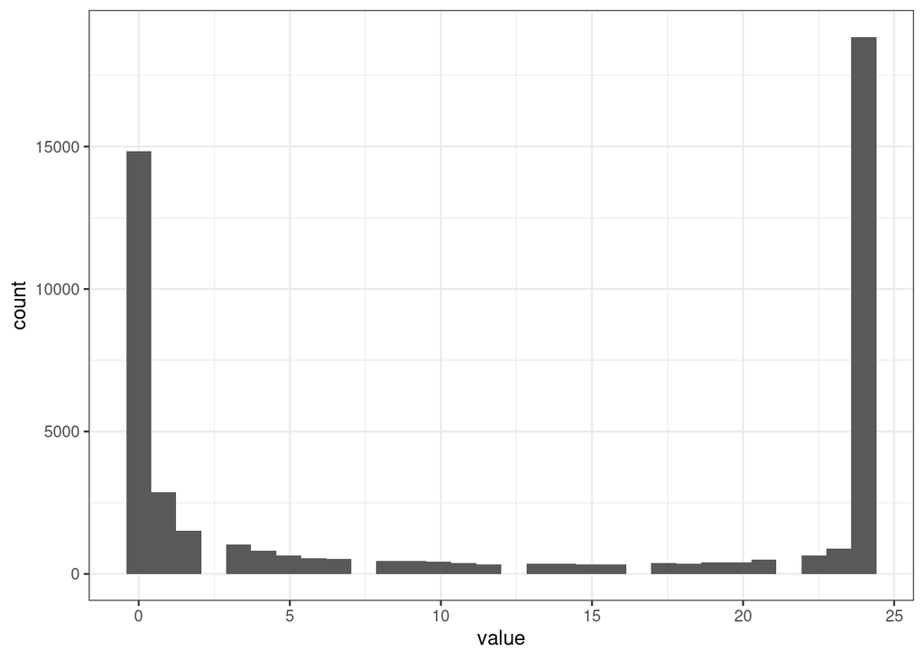

```r
groups <- factor(metadata$group)

dataDGE <- DGEList(counts = gene_expr, group = groups)

cpm(dataDGE) %>%
    apply(1, function(x) {
        sum(x != 0)
    }) %>%
    as_tibble() %>%
    ggplot(aes(x = value)) +
    geom_histogram()
```

```r
# Check how many genes are in our dataset before filtering
dim(dataDGE$counts)
```

```
## [1] 48663    24
```

```r
keptDf <- filterByExpr(dataDGE, min.count = 1)

dataDGE <- dataDGE[keptDf, keep.lib.sizes = FALSE]

# Check how many genes are in our dataset after filtering
# This step gets rid of really lowly expressed genes that can have highly inflated fold changes
dim(dataDGE$counts)
```

```
## [1] 24439    24
```

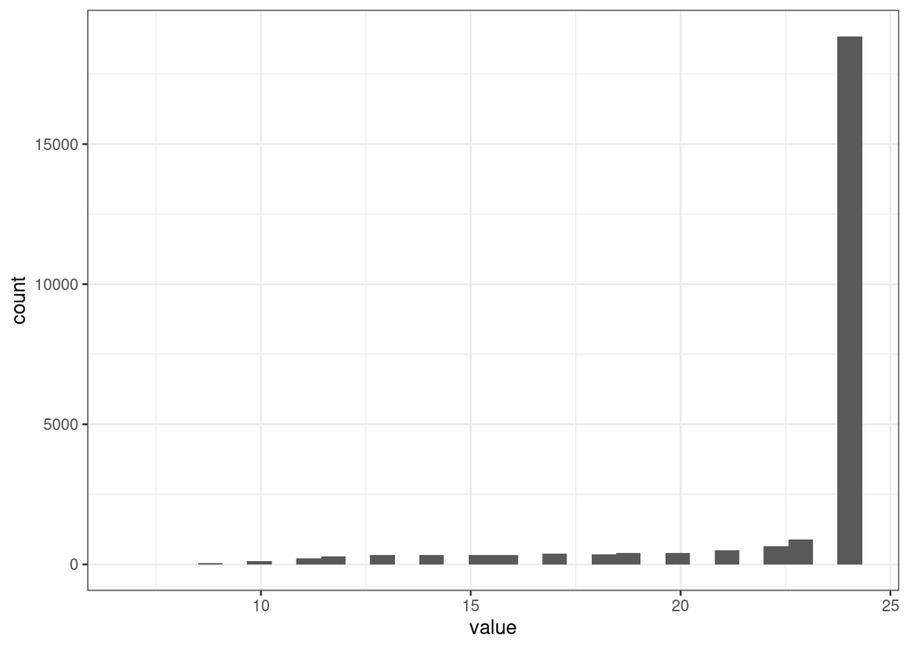

```r
cpm(dataDGE) %>%
    apply(1, function(x) {
        sum(x != 0)
    }) %>%
    as_tibble() %>%
    ggplot(aes(x = value)) +
    geom_histogram()
```

```r
# Generate normalization factors to scale the data across samples by read depth
dataDGE <- calcNormFactors(dataDGE)

dataDGE <- estimateDisp(dataDGE, model.matrix(~ groups))

# Get log transformed normalized counts per million
norm_counts <-
    as.data.frame(cpm(dataDGE, log = TRUE))

# Save the data out to a file
write.table(norm_counts,
            file = "output/de/normCounts.txt",
            col.names = TRUE,
            quote = FALSE,
            sep = "\t")
```